# **NeoNet app**, mapping radiocarbon dating online

Thomas Huet, Niccolo Mazzucco

# Presentation

The **NeoNet app** allows the selection of radiocarbon dating by location, chronology and material life duration by subsetting a radiocarbon dataset according to:

- a geographical region of interest (ROI)
- a time span between a *tpq* and a *taq* in cal BC
- some periods
- some type of material life duration (short like, long life or others)
- a maximum accepted standard deviation threshold (SD)

the [**NeoNet app**](https://neolithic.shinyapps.io/neonet/)

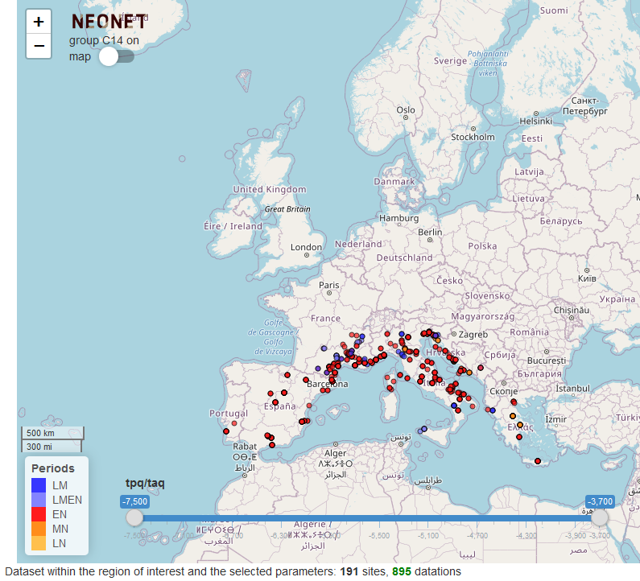

We will see how to use the [**NeoNet app**](https://zoometh.github.io/C14/#app), the **NeoNet database** and how to **participate**

# The **NeoNet database**

The **NeoNet database** is a collaborative online Google Sheet. The database is composed by 3 spreadsheets: **c14**, **material.life** and **period.abrev**

## Database spreadsheets

### c14

This is the complete database. The **mandatory fields** are:

- **SiteName**: the site name
- **Longitude**: in decimal degrees (ex: 1.04573)
- **Latitude**: in decimal degrees (ex: 43.9265)
- **Period**: a value from the **period.abrev** spreadsheet
- **C14Age**: a numerical radiocarbon dating in BP
- **C14SD**: the standard deviation of the radiocarbon dating
- **LabCode**: the unique identifier of the radiocarbon dating
- **Material**: a value from the **material.life** spreadsheet
- **tpq**: the *terminus post quem* of the radiocarbon dating in cal BC
- **taq**: the *terminus ante quem* of the radiocarbon dating in cal BC

The **recommended** fields are:

- **PhaseCode**: a code for the dating stratigaphical unit and/or structure
- **bib**: a plain text bibliographical reference
- **bib_url**: the current URL of the reference or its notice
- **MaterialSpecies**: a specification of the field **Material**
- **Culture**: a specification of the field **Period**

The others fields only concern the **[EUROEVOL_R app](https://zoometh.github.io/C14)**

#### mandatory fields

All these fields are needed to make app working

##### **LabCode**

The correct syntax for a laboratory code (**LabCode**) is ‘*AbrevLab*-*number*’. For example:

| LabCode |
| --- |
| Beta-103487 |
| CSIC-1133 |
| ETH-15984 |
| Gif-1855 |
| KIA-21356 |
| LTL-13440A |
| Ly-11338 |
| MC-2145 |
| OxA-9217 |
| Poz-18393 |
| … |

### material.life

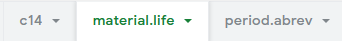

The two fields show the material type and the material life duration, for example:

| material.type | life.duration |
| --- | --- |
| bone | short life |
| seed | short life |
| wood | long life |
| … | … |

You can also [see the entire dataframe](https://htmlpreview.github.io/?https://github.com/zoometh/C14/blob/main/docs/material_life.html)

### period.abrev

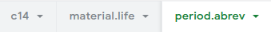

The two fields show the period abreviation and the period full label, for example:

| period.abrev | period |
| --- | --- |
| LM | Late Mesolithic |
| LMEN | Late Mesolithic/Early Neolithic |
| EN | Early Neolithic |
| … | … |

You can also [see the entire dataframe](https://htmlpreview.github.io/?https://github.com/zoometh/C14/blob/main/docs/period_abrev.html)

# How to participate

Thanks to the facilities offer by the app, and in the frame of the **[NeoNet project](https://redneonet.com)**, conducted by [Juan Gibaja](https://orcid.org/0000-0002-0830-3570) and [Miriam Cubas](https://orcid.org/0000-0002-2386-8473), we expect to conduct collaborative spatio-temporal analysis for the origin, the spread and the consolidation of the farming way-of-life in Mediterranean.

To get an access to the permission to edit data, please contact the authors (<thomashuet7@gmail.com >, <nicco.mazzucco@gmail.com >)

## Next developments

In a context of collaborative research and Open Science, for the benefit of the scientific community, good practices and new IT developments are already planned

### Data integration

As data came from various publications:

- an homogenisation the different values must be done
- every radiocarbon dating should be carefully referenced
- license and auhorship should be clearly defined

### Server and database

Today the **NeoNet app** is host on the **[shinyapps.io](https://www.shinyapps.io/)** server, an opensource but limited solution. For example, no direct connection can be done between the app and the database (ie the Google Sheet), so the app have to be *pushed* regularly on the **shinyapps.io** server after the database have been updated (contact <thomashuet7@gmail.com > for this update)

We plan to host the app on a R server in a research institution (University, Laboratory) and to developp a *real* database on [PostgreSQL/PostGIS](https://www.postgresql.org/)

### Open Science

In accordance with the Open Science, we will try to respect the data [**FAIR** principles](https://www.go-fair.org/fair-principles/) (*Findable*, *Accessible*, *Interoperable* & *Reusable*)

## Final objectives

At the middle term we want to:

- publish the archaeological result(s) in scientific paper(s)
- publish the **NeoNet app** development in a digital humanities papers
- present the results and the app in conferences, seminars, etc.
- present the app in dedicated workshops
- publish as FAIR open-source data the **NeoNet app** source code and a selection of the radiocarbon dataset